# Clustering 1: Puntos en el plano

Vamos a realizar un estudio de clustering con un conjunto de datos en dos dimensiones.

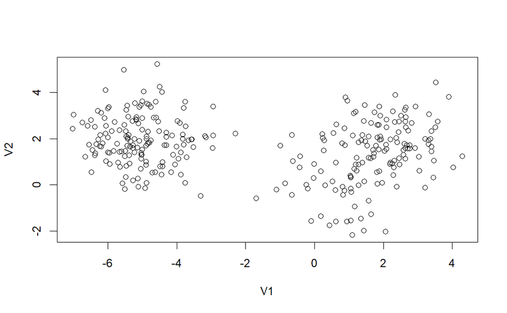

```r
#Lectura del dataset
puntos <- read.delim("data/toy_example.txt",
                     sep = "\t",
                     head = FALSE)

#Visualización del dataset
plot(puntos)
```

Le echamos un vistazo a los datos.

```r
head(puntos)
```

|  | V1 | V2 |
| --- | --- | --- |
| 1 | 3.370958 | 1.995379 |
| 2 | 1.435302 | 2.760242 |
| 3 | 2.363128 | 2.038991 |
| 4 | 2.632863 | 2.735072 |
| 5 | 2.404268 | 1.853527 |
| 6 | 1.893875 | 1.942113 |

```r
str(puntos)
```

```
'data.frame':   300 obs. of  2 variables:
 $ V1: num  3.37 1.44 2.36 2.63 2.4 ...
 $ V2: num  2 2.76 2.04 2.74 1.85 ...
```

```r
dim(puntos)
```

```
[1] 300   2
```

# Algoritmo k-Means

```r
km_puntos <- kmeans(puntos, centers = 3, nstar=20)
km_puntos
```

```
K-means clustering with 3 clusters of sizes 150, 98, 52

Cluster means:
          V1          V2
1 -5.0556758  1.96991743
2  2.2171113  2.05110690
3  0.6642455 -0.09132968

Clustering vector:
  [1] 2 2 2 2 2 2 2 2 2 2 2 2 3 2 2 2 2 3 3 2 2 2 2 2 2 2 2 2 2 2 2 2 2 2 2 2 3
 [38] 3 3 2 2 2 2 3 2 2 2 2 2 2 2 2 2 2 2 2 2 2 3 2 2 2 2 2 2 2 2 2 2 2 2 2 2 3
 [75] 2 2 2 2 2 2 2 2 2 2 2 2 2 2 2 2 2 2 2 2 2 2 2 2 2 2 1 1 1 1 1 1 1 1 1 1 1
[112] 1 1 1 1 1 1 1 1 1 1 1 1 1 1 1 1 1 1 1 1 1 1 1 1 1 1 1 1 1 1 1 1 1 1 1 1 1
[149] 1 1 1 1 1 1 1 1 1 1 1 1 1 1 1 1 1 1 1 1 1 1 1 1 1 1 1 1 1 1 1 1 1 1 1 1 1
[186] 1 1 1 1 1 1 1 1 1 1 1 1 1 1 1 1 1 1 1 1 1 1 1 1 1 1 1 1 1 1 1 1 1 1 1 1 1
[223] 1 1 1 1 1 1 1 1 1 1 1 1 1 1 1 1 1 1 1 1 1 1 1 1 1 1 1 1 3 3 3 3 2 3 3 3 3
[260] 3 3 3 3 3 3 3 3 3 3 3 3 3 3 3 3 2 2 3 3 2 3 3 3 3 3 3 2 3 3 3 3 3 3 2 3 3
[297] 3 2 3 3

Within cluster sum of squares by cluster:
[1] 295.16925 148.64781  95.50625
 (between_SS / total_SS =  87.2 %)

Available components:

[1] "cluster"      "centers"      "totss"        "withinss"     "tot.withinss"
[6] "betweenss"    "size"         "iter"         "ifault"
```

```r
#summary(km_puntos) <-- Parámetros del algoritmo
km_puntos$cluster
```

```
  [1] 2 2 2 2 2 2 2 2 2 2 2 2 3 2 2 2 2 3 3 2 2 2 2 2 2 2 2 2 2 2 2 2 2 2 2 2 3
 [38] 3 3 2 2 2 2 3 2 2 2 2 2 2 2 2 2 2 2 2 2 2 3 2 2 2 2 2 2 2 2 2 2 2 2 2 2 3
 [75] 2 2 2 2 2 2 2 2 2 2 2 2 2 2 2 2 2 2 2 2 2 2 2 2 2 2 1 1 1 1 1 1 1 1 1 1 1
[112] 1 1 1 1 1 1 1 1 1 1 1 1 1 1 1 1 1 1 1 1 1 1 1 1 1 1 1 1 1 1 1 1 1 1 1 1 1
[149] 1 1 1 1 1 1 1 1 1 1 1 1 1 1 1 1 1 1 1 1 1 1 1 1 1 1 1 1 1 1 1 1 1 1 1 1 1
[186] 1 1 1 1 1 1 1 1 1 1 1 1 1 1 1 1 1 1 1 1 1 1 1 1 1 1 1 1 1 1 1 1 1 1 1 1 1
[223] 1 1 1 1 1 1 1 1 1 1 1 1 1 1 1 1 1 1 1 1 1 1 1 1 1 1 1 1 3 3 3 3 2 3 3 3 3
[260] 3 3 3 3 3 3 3 3 3 3 3 3 3 3 3 3 2 2 3 3 2 3 3 3 3 3 3 2 3 3 3 3 3 3 2 3 3
[297] 3 2 3 3
```

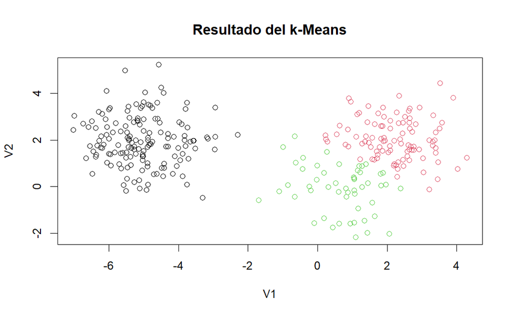

```r
plot(puntos,
     col=km_puntos$cluster, #colorea según los cluster del kMeans
     main="Resultado del k-Means")
```

## Estudio sobre la aleatoriedad del k-Means

Para esto vamos a realizar un pequeño experimento ejecutando varias veces el algoritmo.

Vamos a estudiar cómo influye el valor del parámetro nstart.

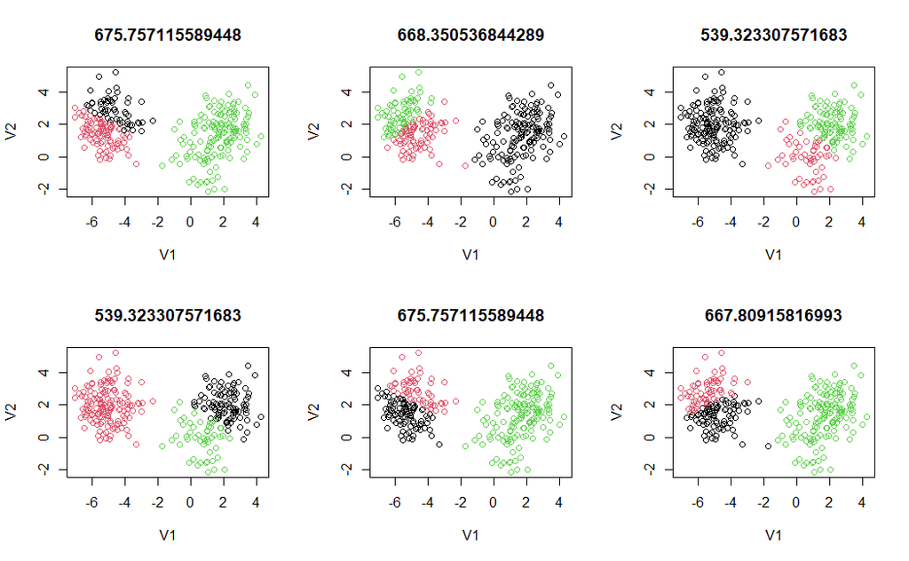

```r
par(mfrow=c(2,3)) #Para mostrar una rejilla de 2x3

for(i in 1:6){
  #nstar=1
  km_puntos_aux <- kmeans(puntos, center=3, nstart=1)
  plot(puntos, col=km_puntos_aux$cluster, main=km_puntos_aux$tot.withinss)
}
```

Se obtienen resultados de la compacidad muy diferentes entre sí.

Ahora repetimos el experimento cambiando el valor del parámetro nstar=20

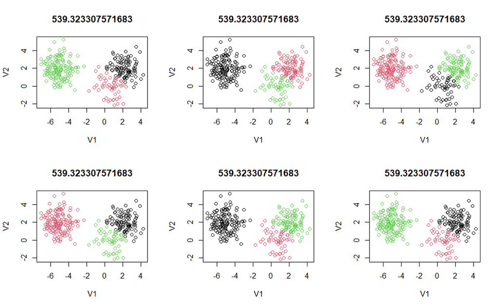

```r
par(mfrow=c(2,3)) #Para mostrar una rejilla de 2x3

for(i in 1:6){
  #nstar=1
  km_puntos_aux <- kmeans(puntos, center=3, nstart=20)
  plot(puntos, col=km_puntos_aux$cluster, main=km_puntos_aux$tot.withinss)
}
```

La compacidad de la función mejora y además se queda estable.

## Estudio sobre el parámetro k del K-means (center)

En función de la compactación podemos tener alguna pauta de elección del valor de k

El algoritmo funciona y escala muy bien pero tiene el gran inconveniente de que hay que imponer el valor k.

Experimento: ejecutamos 15 veces el kmeans y estudiamos los resultados. En función de esta información elegimos el valor de k

¿Para qué valor de k varía drásticamente el valor de k?

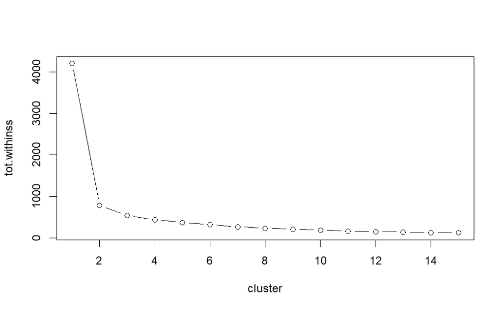

```r
#Ejecuta 15 veces variando el valor de k

vector_compactacion <- 0

for(i in 1:15){
  km_puntos_center <- kmeans(puntos, center = i, nstart = 20)
  vector_compactacion[i] <- km_puntos_center$tot.withinss
}

#Representa los valores de la compactación

par(mfrow=c(1,1)) #Para quitar la rejilla

plot(1:15, vector_compactacion,
     type = "b",
     xlab = "cluster", ylab="tot.withinss")
```

```r
NA
NA
NA
```